# 31010 - Assignment 7

Melanie Tran

3/2/2021

**1) The data ‘car ins claims.csv’ contain the number of car insurance policies, n, and number of claims, y, by various insurance categories, CAR, age of policy holder, AGE, and district where the policy holder lived (DIST=1, for London and other major cities and DIST=0, otherwise).**

```r
car <- read.csv("car ins claims.csv", header = TRUE)
head(car)
```

```
##   CAR AGE DIST   y    n
## 1   1   1    0  65  317
## 2   1   2    0  65  476
## 3   1   3    0  52  486
## 4   1   4    0 310 3259
## 5   2   1    0  98  486
## 6   2   2    0 159 1004
```

**1A) Calculate the rate of claims y/n for each category and plot the rates by AGE, CAR and DIST to get an idea of the main effects of these factors.**

```r
rate <- car$y/car$n
car <- cbind(car,rate)
car
```

```
##    CAR AGE DIST   y    n      rate
## 1    1   1    0  65  317 0.2050473
## 2    1   2    0  65  476 0.1365546
## 3    1   3    0  52  486 0.1069959
## 4    1   4    0 310 3259 0.0951212
## 5    2   1    0  98  486 0.2016461
## 6    2   2    0 159 1004 0.1583665
## 7    2   3    0 175 1355 0.1291513
## 8    2   4    0 877 7660 0.1144909
## 9    3   1    0  41  223 0.1838565
## 10   3   2    0 117  539 0.2170686
## 11   3   3    0 137  697 0.1965567
## 12   3   4    0 477 3442 0.1385822
## 13   4   1    0  11   40 0.2750000
## 14   4   2    0  35  148 0.2364865
```

[output cut: 18 more lines]

Plot the graphs.

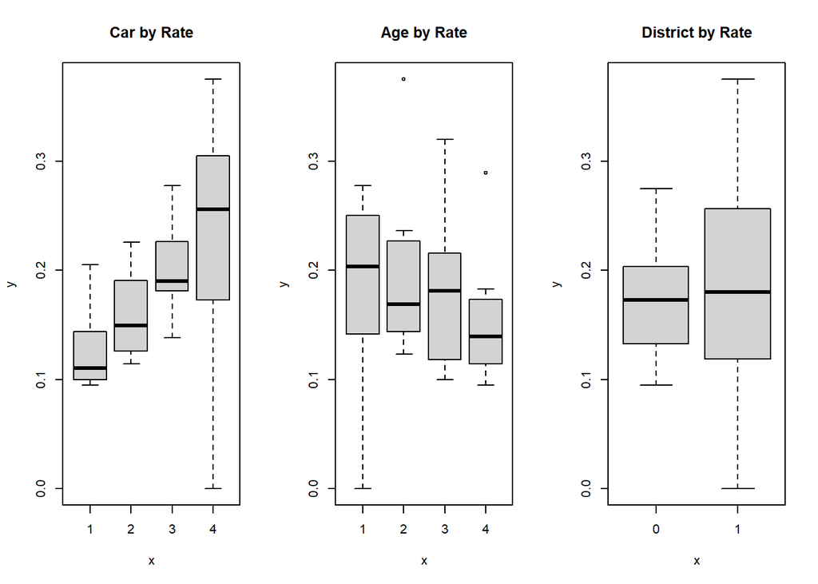

```r
par(mfrow=c(1, 3))
plot(factor(car$CAR), car$rate, main="Car by Rate")
plot(factor(car$AGE), car$rate, main="Age by Rate")
plot(factor(car$DIST), car$rate, main="District by Rate")
```

**1B) Use Poisson regression to estimate the main effects (each treated as categorical and modelled using indicator variables) and interaction terms.**

```r
m1 <- glm(y~offset(log(n)) +
            factor(CAR) +
            factor(AGE) +
            factor(DIST) ,data=car,family=poisson(link = "log"))
summary(m1)
```

```
##
## Call:
## glm(formula = y ~ offset(log(n)) + factor(CAR) + factor(AGE) +
##     factor(DIST), family = poisson(link = "log"), data = car)
##
## Deviance Residuals:
##     Min       1Q   Median       3Q      Max
## -1.8588  -0.6371  -0.1555   0.3749   1.7536
##
## Coefficients:
##               Estimate Std. Error z value Pr(>|z|)
## (Intercept)   -1.81021    0.07532 -24.034  < 2e-16 ***
## factor(CAR)2   0.16229    0.05052   3.213 0.001315 **
## factor(CAR)3   0.39352    0.05498   7.157 8.25e-13 ***
## factor(CAR)4   0.56540    0.07228   7.823 5.18e-15 ***
## factor(AGE)2  -0.18902    0.08282  -2.282 0.022477 *
## factor(AGE)3  -0.34211    0.08130  -4.208 2.58e-05 ***
## factor(AGE)4  -0.53275    0.06979  -7.634 2.28e-14 ***
## factor(DIST)1  0.21850    0.05853   3.733 0.000189 ***
## ---
## Signif. codes:  0 '***' 0.001 '**' 0.01 '*' 0.05 '.' 0.1 ' ' 1
##
## (Dispersion parameter for poisson family taken to be 1)
##
##     Null deviance: 207.833  on 31  degrees of freedom
## Residual deviance:  23.709  on 24  degrees of freedom
## AIC: 208.07
##
## Number of Fisher Scoring iterations: 4
```

**1C) Fit a Poisson regression model by treating CAR and AGE as continuous variables.**

```r
m2 <- glm(y~offset(log(n)) + CAR + AGE + factor(DIST),data=car,family=poisson(link = "log"))
summary(m2)
```

```
##
## Call:
## glm(formula = y ~ offset(log(n)) + CAR + AGE + factor(DIST),
##     family = poisson(link = "log"), data = car)
##
## Deviance Residuals:
##     Min       1Q   Median       3Q      Max
## -1.7248  -0.5681  -0.1679   0.3384   1.9126
##
## Coefficients:
##               Estimate Std. Error z value Pr(>|z|)
## (Intercept)   -1.85253    0.07990 -23.185  < 2e-16 ***
## CAR            0.19777    0.02080   9.507  < 2e-16 ***
## AGE           -0.17674    0.01849  -9.559  < 2e-16 ***
## factor(DIST)1  0.21865    0.05853   3.736 0.000187 ***
## ---
## Signif. codes:  0 '***' 0.001 '**' 0.01 '*' 0.05 '.' 0.1 ' ' 1
##
## (Dispersion parameter for poisson family taken to be 1)
##
##     Null deviance: 207.833  on 31  degrees of freedom
## Residual deviance:  24.685  on 28  degrees of freedom
## AIC: 201.05
##
## Number of Fisher Scoring iterations: 4
```

**2) The dataset ‘Insurance.RData’ in the R package MASS consists of the numbers of policyholders of an insurance company who were exposed to risk, and the numbers of car insurance claims made by those policyholders in the third quarter of 1973. Please visit (https://stat.ethz.ch/R-manual/R-devel/library/MASS/html/Insurance.html) for variable descriptions.**

- District - factor: district of residence of policyholder (1 to 4): 4 is major cities.
- Group - an ordered factor: group of car with levels <1 litre, 1–1.5 litre, 1.5–2 litre, >2 litre.
- Age - an ordered factor: the age of the insured in 4 groups labeled <25, 25–29, 30–35, >35.
- Holders - numbers of policyholders (n)
- Claims - numbers of claims (y)

```r
library(MASS)
data("Insurance")
Insurance
```

```
##    District  Group   Age Holders Claims
## 1         1    <1l   <25     197     38
## 2         1    <1l 25-29     264     35
## 3         1    <1l 30-35     246     20
## 4         1    <1l   >35    1680    156
## 5         1 1-1.5l   <25     284     63
## 6         1 1-1.5l 25-29     536     84
## 7         1 1-1.5l 30-35     696     89
## 8         1 1-1.5l   >35    3582    400
## 9         1 1.5-2l   <25     133     19
## 10        1 1.5-2l 25-29     286     52
## 11        1 1.5-2l 30-35     355     74
## 12        1 1.5-2l   >35    1640    233
## 13        1    >2l   <25      24      4
## 14        1    >2l 25-29      71     18
```

[output cut: 50 more lines]

**A) Conduct an exploratory data analysis.**

```r
library("psych")
describe(Insurance)
```

```
##           vars  n   mean     sd median trimmed    mad min  max range skew
## District*    1 64   2.50   1.13    2.5    2.50   1.48   1    4     3 0.00
## Group*       2 64   2.50   1.13    2.5    2.50   1.48   1    4     3 0.00
## Age*         3 64   2.50   1.13    2.5    2.50   1.48   1    4     3 0.00
## Holders      4 64 364.98 622.77  136.0  215.31 162.34   3 3582  3579 3.13
## Claims       5 64  49.23  71.16   22.0   33.21  24.46   0  400   400 2.88
##           kurtosis    se
## District*    -1.41  0.14
## Group*       -1.41  0.14
## Age*         -1.41  0.14
## Holders      11.00 77.85
## Claims        9.38  8.90
```

Calculate Counts

```r
## look at the counts of the data
lapply(Insurance[, c("District","Group","Age","Holders", "Claims")], table)
```

```
## $District
##
##  1  2  3  4
## 16 16 16 16
##
## $Group
##
##    <1l 1-1.5l 1.5-2l    >2l
##     16     16     16     16
##
## $Age
##
##   <25 25-29 30-35   >35
##    16    16    16    16
##
## $Holders
##
##    3    7    9   16   18   20   24   25   29   31   33   35   39   40   43   48
##    1    1    1    1    1    1    2    1    1    1    1    1    1    1    1    1
##   53   66   68   71   72   73   78   81   85   89   99  114  121  122  133  139
##    1    1    1    1    1    1    1    1    1    1    1    1    1    1    1    1
##  149  151  155  175  197  221  240  245  246  264  284  286  313  316  322  344
##    1    1    1    1    1    1    1    1    1    1    1    1    1    1    1    1
##  355  419  452  536  648  692  696  724  931 1110 1635 1640 1680 2443 3582
##    1    1    1    1    1    1    1    1    1    1    1    1    1    1    1
##
## $Claims
##
##   0   2   3   4   5   6   7   8  10  11  12  14  15  16  18  19  20  22  24  25
##   1   2   1   3   3   1   2   3   3   1   1   1   1   1   1   4   1   3   2   1
##  33  35  36  37  38  39  46  49  51  52  53  63  67  74  77  84  87  89 101 102
##   1   1   1   2   1   1   1   1   1   1   1   2   1   1   1   1   1   1   1   1
## 143 156 187 233 290 400
##   1   1   1   1   1   1
```

Check for NAs.

```r
is.na(Insurance)
```

```
##    District Group   Age Holders Claims
## 1     FALSE FALSE FALSE   FALSE  FALSE
## 2     FALSE FALSE FALSE   FALSE  FALSE
## 3     FALSE FALSE FALSE   FALSE  FALSE
## 4     FALSE FALSE FALSE   FALSE  FALSE
## 5     FALSE FALSE FALSE   FALSE  FALSE
## 6     FALSE FALSE FALSE   FALSE  FALSE
## 7     FALSE FALSE FALSE   FALSE  FALSE
## 8     FALSE FALSE FALSE   FALSE  FALSE
## 9     FALSE FALSE FALSE   FALSE  FALSE
## 10    FALSE FALSE FALSE   FALSE  FALSE
## 11    FALSE FALSE FALSE   FALSE  FALSE
## 12    FALSE FALSE FALSE   FALSE  FALSE
## 13    FALSE FALSE FALSE   FALSE  FALSE
## 14    FALSE FALSE FALSE   FALSE  FALSE
```

[output cut: 50 more lines]

Calculate correlation.

```r
num_district <- as.numeric(Insurance$District)
num_group <- as.numeric(Insurance$Group)
num_age <- as.numeric(Insurance$Age)
num_holders <- as.numeric(Insurance$Holders)
num_claims <- as.numeric(Insurance$Claims)

corr_insur <- cbind(num_district,num_group,num_age,num_holders,num_claims)
cor(corr_insur, method = "pearson")
```

```
##              num_district  num_group   num_age num_holders num_claims
## num_district    1.0000000  0.0000000 0.0000000  -0.3182257 -0.3466924
## num_group       0.0000000  1.0000000 0.0000000  -0.1831729 -0.1293540
## num_age         0.0000000  0.0000000 1.0000000   0.5416023  0.5499770
## num_holders    -0.3182257 -0.1831729 0.5416023   1.0000000  0.9857701
## num_claims     -0.3466924 -0.1293540 0.5499770   0.9857701  1.0000000
```

**RESULTS:** There seems to be some correlation between Age and Holders (0.54) and between Age and Claims (0.55)

Calculate insurance rate.

```r
#identify rate
insurance_rate = Insurance$Claims/Insurance$Holders

#bind to the data table
dta <- cbind(Insurance,insurance_rate)
head(dta)
```

```
##   District  Group   Age Holders Claims insurance_rate
## 1        1    <1l   <25     197     38     0.19289340
## 2        1    <1l 25-29     264     35     0.13257576
## 3        1    <1l 30-35     246     20     0.08130081
## 4        1    <1l   >35    1680    156     0.09285714
## 5        1 1-1.5l   <25     284     63     0.22183099
## 6        1 1-1.5l 25-29     536     84     0.15671642
```

Plot data.

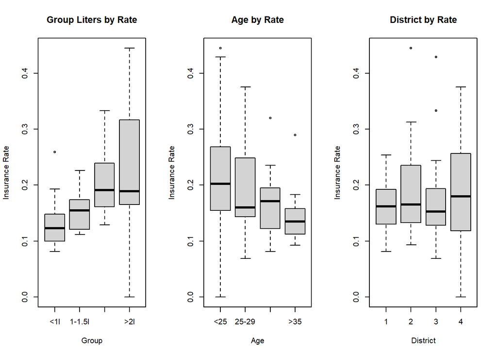

```r
par(mfrow=c(1, 3))
plot(dta$Group, dta$insurance_rate, main="Group Liters by Rate", xlab = "Group", ylab = "Insurance Rate")
plot(dta$Age, dta$insurance_rate, main="Age by Rate", xlab = "Age", ylab = "Insurance Rate")
plot(dta$District, dta$insurance_rate, main="District by Rate", xlab = "District", ylab = "Insurance Rate")
```

**B) Estimate the Poisson model with District, Group and Age as categorical variables. Do you spot any potential improvements to the model?**

```r
m3 <- glm(Claims ~offset(log(Holders)) +
            factor(District) +
            factor(Group) +
            factor(Age),data=dta,family=poisson(link = "log"))
summary(m3)
```

```
##
## Call:
## glm(formula = Claims ~ offset(log(Holders)) + factor(District) +
##     factor(Group) + factor(Age), family = poisson(link = "log"),
##     data = dta)
##
## Deviance Residuals:
##      Min        1Q    Median        3Q       Max
## -2.46558  -0.50802  -0.03198   0.55555   1.94026
##
## Coefficients:
##                    Estimate Std. Error z value Pr(>|z|)
## (Intercept)       -1.810508   0.032972 -54.910  < 2e-16 ***
## factor(District)2  0.025868   0.043016   0.601 0.547597
## factor(District)3  0.038524   0.050512   0.763 0.445657
## factor(District)4  0.234205   0.061673   3.798 0.000146 ***
## factor(Group).L    0.429708   0.049459   8.688  < 2e-16 ***
## factor(Group).Q    0.004632   0.041988   0.110 0.912150
## factor(Group).C   -0.029294   0.033069  -0.886 0.375696
## factor(Age).L     -0.394432   0.049404  -7.984 1.42e-15 ***
## factor(Age).Q     -0.000355   0.048918  -0.007 0.994210
## factor(Age).C     -0.016737   0.048478  -0.345 0.729910
## ---
## Signif. codes:  0 '***' 0.001 '**' 0.01 '*' 0.05 '.' 0.1 ' ' 1
##
## (Dispersion parameter for poisson family taken to be 1)
##
##     Null deviance: 236.26  on 63  degrees of freedom
## Residual deviance:  51.42  on 54  degrees of freedom
## AIC: 388.74
##
## Number of Fisher Scoring iterations: 4
```

```r
num_m3 <- glm(Claims ~offset(log(Holders)) +
            as.numeric(Group) +
            as.numeric(Age) +
            as.numeric(District),data=dta,family=poisson(link = "log"))
summary(num_m3)
```

```
##
## Call:
## glm(formula = Claims ~ offset(log(Holders)) + as.numeric(Group) +
##     as.numeric(Age) + as.numeric(District), family = poisson(link = "log"),
##     data = dta)
##
## Deviance Residuals:
##      Min        1Q    Median        3Q       Max
## -2.43592  -0.53731   0.02263   0.64643   2.13659
##
## Coefficients:
##                      Estimate Std. Error z value Pr(>|z|)
## (Intercept)          -1.92739    0.08479 -22.732   <2e-16 ***
## as.numeric(Group)     0.19715    0.02081   9.474   <2e-16 ***
## as.numeric(Age)      -0.17923    0.01854  -9.667   <2e-16 ***
## as.numeric(District)  0.05488    0.01792   3.062   0.0022 **
## ---
## Signif. codes:  0 '***' 0.001 '**' 0.01 '*' 0.05 '.' 0.1 ' ' 1
##
## (Dispersion parameter for poisson family taken to be 1)
##
##     Null deviance: 236.259  on 63  degrees of freedom
## Residual deviance:  57.027  on 60  degrees of freedom
## AIC: 382.35
##
## Number of Fisher Scoring iterations: 4
```

**c) Interpret at least two coefficients of the model in B)**

- For number of Holders that reside in District 4, there is a 23% increase in number of claims filed, holding constant all other variables.
- For number of Holders that are in Age for cubic levels, there is a 1.6% decrease in number of claims filed, holding constant all other variables.

**3) The dataset ‘medicare.RData’ contains information on the number of visits to physicians by Medicare participants. It also contain information on each participant including:** - hospital stays (numHospStays)

- self health status assessment (statusHealth)
- chronic conditions count (numChronic)
- gender
- years of education (numYearsEduc)
- private insurance (hasPrivIns)
- numVisits (y)

```r
load("C:/Users/meltra02/Desktop/MSCA/Quarter 2/31010 - Linear Nonlinear/31010 - Assignment - 7/medicare.RData")
head(medicare)
```

```
##   numVisits numHospStays statusHealth numChronic gender numYearsEduc hasPrivIns
## 1         5            1      average          2   male            6        yes
## 2         1            0      average          2 female           10        yes
## 3        13            3         poor          4 female           10         no
## 4        16            1         poor          2   male            3        yes
## 5         3            0      average          2 female            6        yes
## 6        17            0         poor          5 female            7         no
```

```r
describe(medicare)
```

```
##               vars    n  mean   sd median trimmed  mad min max range  skew
## numVisits        1 3723  6.83 6.84      5    5.68 4.45   1  89    88  3.45
## numHospStays     2 3723  0.32 0.77      0    0.14 0.00   0   8     8  3.79
## statusHealth*    3 3723  1.34 0.70      1    1.17 0.00   1   3     2  1.76
## numChronic       4 3723  1.66 1.35      1    1.51 1.48   0   8     8  0.91
## gender*          5 3723  1.39 0.49      1    1.36 0.00   1   2     1  0.45
## numYearsEduc     6 3723 10.45 3.68     12   10.58 2.97   0  18    18 -0.44
## hasPrivIns*      7 3723  1.80 0.40      2    1.88 0.00   1   2     1 -1.50
##               kurtosis   se
## numVisits        20.76 0.11
## numHospStays     21.19 0.01
## statusHealth*     1.36 0.01
## numChronic        0.67 0.02
## gender*          -1.79 0.01
## numYearsEduc      0.30 0.06
## hasPrivIns*       0.26 0.01
```

**A) Prepare box plots of the number of visits to physicians against each of the variables. You may place numerical explanatory variables into a category (e.g., 3+ years of education). Plot the histogram for the number of visits.**

```r
## create loop to categorize numHospStays
n = length(medicare$numHospStays)
catHosp = numeric(n)
for (i in (1:n)) {
        if (medicare$numHospStays[i] <= 4) {
                catHosp[i] <-  "0-4"
        } else {
          catHosp[i] <-  "4-8"
        }

}

## create loop to categorize numChronic
n = length(medicare$numChronic)
catChronic = numeric(n)
for (i in (1:n)) {
        if (medicare$numChronic[i] <= 4) {
                catChronic[i] <-  "0-4"
        } else {
          catChronic[i] <-  "4-8"
        }

}

## create loop to categorize years of education
n = length(medicare$numYearsEduc)
catEdu = numeric(n)
for (i in (1:n)) {
        if (medicare$numYearsEduc[i] <= 3) {
                catEdu[i] <-  "0-3"
        } else if (medicare$numYearsEduc[i] <= 6) {
                catEdu[i] <-  "4-6"
        } else {
          catEdu[i] <-  "6+"
        }

}
```

```r
# view counts by education category
table(unlist(catEdu))
```

```
##
##  0-3  4-6   6+
##  170  295 3258
```

```r
# view counts by hospital visits category
table(unlist(catHosp))
```

```
##
##  0-4  4-8
## 3704   19
```

```r
# view counts by chronic conditions category
table(unlist(catChronic))
```

```
##
##  0-4  4-8
## 3561  162
```

```r
# add categorical Hosp, Chronic, Edu back to medicare data frame

medicare <- cbind(medicare, catHosp, catChronic, catEdu)
head(medicare)
```

```
##   numVisits numHospStays statusHealth numChronic gender numYearsEduc hasPrivIns
## 1         5            1      average          2   male            6        yes
## 2         1            0      average          2 female           10        yes
## 3        13            3         poor          4 female           10         no
## 4        16            1         poor          2   male            3        yes
## 5         3            0      average          2 female            6        yes
## 6        17            0         poor          5 female            7         no
##   catHosp catChronic catEdu
## 1     0-4        0-4    4-6
## 2     0-4        0-4     6+
## 3     0-4        0-4     6+
## 4     0-4        0-4    0-3
## 5     0-4        0-4    4-6
## 6     0-4        4-8     6+
```

Plot graphs with Medicare predictors as given and factor(Years of Education).

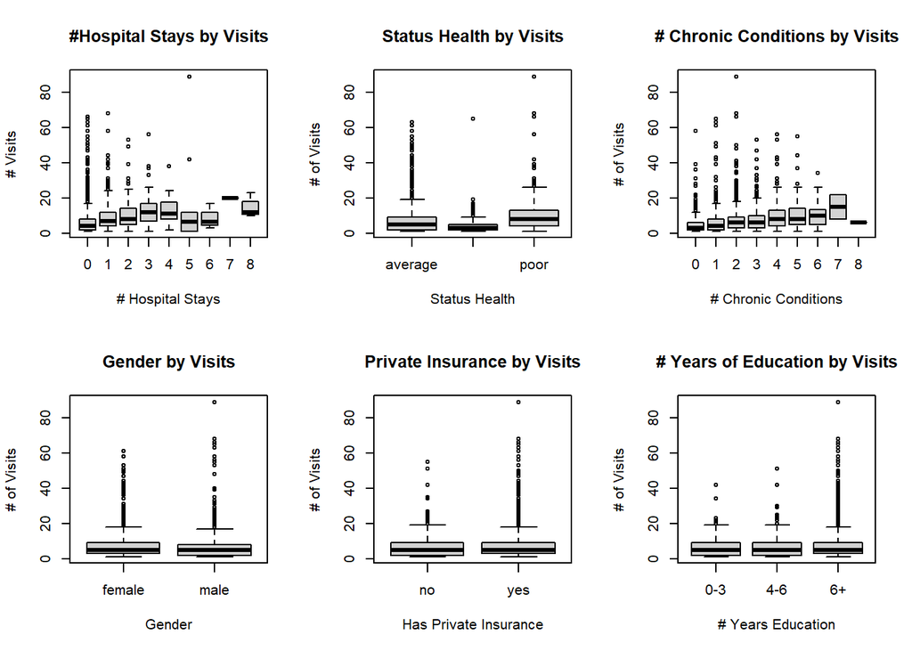

```r
par(mfrow=c(2, 3))
plot(factor(medicare$numHospStays), medicare$numVisits, main="#Hospital Stays by Visits", xlab = "# Hospital Stays", ylab = "# Visits")
plot(medicare$statusHealth, medicare$numVisits, main="Status Health by Visits", xlab = "Status Health", ylab = "# of Visits")
plot(factor(medicare$numChronic), medicare$numVisits, main="# Chronic Conditions by Visits", xlab = "# Chronic Conditions", ylab = "# of Visits")
plot(medicare$gender, medicare$numVisits, main="Gender by Visits", xlab = "Gender", ylab = "# of Visits")
plot(medicare$hasPrivIns, medicare$numVisits, main="Private Insurance by Visits", xlab = "Has Private Insurance", ylab = "# of Visits")
plot(factor(medicare$catEdu), medicare$numVisits, main="# Years of Education by Visits", xlab = "# Years Education", ylab = "# of Visits")
```

Plot the graphs will all predictors as factors.

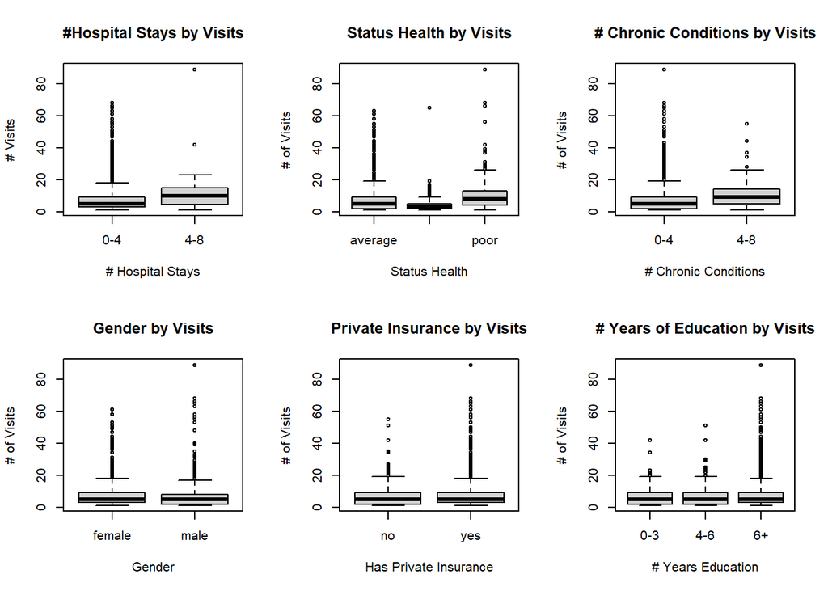

```r
par(mfrow=c(2, 3))
plot(factor(medicare$catHosp), medicare$numVisits, main="#Hospital Stays by Visits", xlab = "# Hospital Stays", ylab = "# Visits")
plot(medicare$statusHealth, medicare$numVisits, main="Status Health by Visits", xlab = "Status Health", ylab = "# of Visits")
plot(factor(medicare$catChronic), medicare$numVisits, main="# Chronic Conditions by Visits", xlab = "# Chronic Conditions", ylab = "# of Visits")
plot(medicare$gender, medicare$numVisits, main="Gender by Visits", xlab = "Gender", ylab = "# of Visits")
plot(medicare$hasPrivIns, medicare$numVisits, main="Private Insurance by Visits", xlab = "Has Private Insurance", ylab = "# of Visits")
plot(factor(medicare$catEdu), medicare$numVisits, main="# Years of Education by Visits", xlab = "# Years Education", ylab = "# of Visits")
```

Plot the histogram for the number of visits.

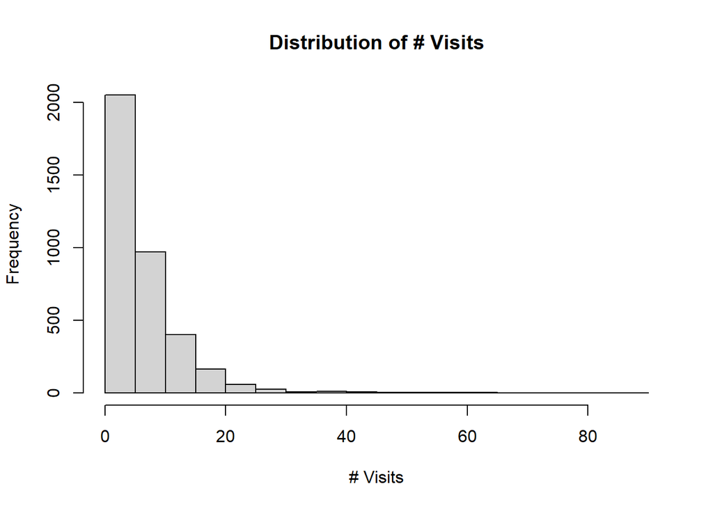

```r
hist(medicare$numVisits,main = "Distribution of # Visits", xlab = "# Visits")
```

**B) Run a Poisson regression with the explanatory variables listed above.**

```r
modMediPois <- glm(numVisits ~ numHospStays +
            statusHealth +
            numChronic +
            gender +
            catEdu + #factored EDU
            hasPrivIns,data=medicare,family=poisson(link = "log"))
summary(modMediPois)
```

```
##
## Call:
## glm(formula = numVisits ~ numHospStays + statusHealth + numChronic +
##     gender + catEdu + hasPrivIns, family = poisson(link = "log"),
##     data = medicare)
##
## Deviance Residuals:
##     Min       1Q   Median       3Q      Max
## -5.7853  -1.7173  -0.6808   0.7123  15.1454
##
## Coefficients:
##                        Estimate Std. Error z value Pr(>|z|)
## (Intercept)            1.511738   0.032828  46.051  < 2e-16 ***
## numHospStays           0.157775   0.006056  26.051  < 2e-16 ***
## statusHealthexcellent -0.273234   0.030253  -9.032  < 2e-16 ***
## statusHealthpoor       0.236919   0.017649  13.424  < 2e-16 ***
## numChronic             0.099738   0.004692  21.255  < 2e-16 ***
## gendermale            -0.057613   0.012975  -4.440 8.99e-06 ***
## catEdu4-6              0.031843   0.037115   0.858   0.3909
## catEdu6+               0.078722   0.031146   2.527   0.0115 *
## hasPrivInsyes          0.117950   0.016898   6.980 2.95e-12 ***
## ---
## Signif. codes:  0 '***' 0.001 '**' 0.01 '*' 0.05 '.' 0.1 ' ' 1
##
## (Dispersion parameter for poisson family taken to be 1)
##
##     Null deviance: 18372  on 3722  degrees of freedom
## Residual deviance: 16171  on 3714  degrees of freedom
## AIC: 28965
##
## Number of Fisher Scoring iterations: 5
```

**C) Run the quasi-Poisson regression with the explanatory variables listed above. Do you see any evidence of over-dispersion? Explain. Would your assessment of the significance of each variable change from the model in item B)? Explain.**

```r
modMediQP <- glm(numVisits ~ numHospStays +
            statusHealth +
            numChronic +
            gender +
            catEdu +
            hasPrivIns,data=medicare,family=quasipoisson(link = "log"))
summary(modMediQP)
```

```
##
## Call:
## glm(formula = numVisits ~ numHospStays + statusHealth + numChronic +
##     gender + catEdu + hasPrivIns, family = quasipoisson(link = "log"),
##     data = medicare)
##
## Deviance Residuals:
##     Min       1Q   Median       3Q      Max
## -5.7853  -1.7173  -0.6808   0.7123  15.1454
##
## Coefficients:
##                       Estimate Std. Error t value Pr(>|t|)
## (Intercept)            1.51174    0.08023  18.842  < 2e-16 ***
## numHospStays           0.15777    0.01480  10.659  < 2e-16 ***
## statusHealthexcellent -0.27323    0.07394  -3.695 0.000223 ***
## statusHealthpoor       0.23692    0.04313   5.493 4.23e-08 ***
## numChronic             0.09974    0.01147   8.697  < 2e-16 ***
## gendermale            -0.05761    0.03171  -1.817 0.069335 .
## catEdu4-6              0.03184    0.09071   0.351 0.725575
## catEdu6+               0.07872    0.07612   1.034 0.301131
## hasPrivInsyes          0.11795    0.04130   2.856 0.004315 **
## ---
## Signif. codes:  0 '***' 0.001 '**' 0.01 '*' 0.05 '.' 0.1 ' ' 1
##
## (Dispersion parameter for quasipoisson family taken to be 5.973159)
##
##     Null deviance: 18372  on 3722  degrees of freedom
## Residual deviance: 16171  on 3714  degrees of freedom
## AIC: NA
##
## Number of Fisher Scoring iterations: 5
```

Calculating over-dispersion by hand.

```r
dpQP <- sum(residuals(modMediQP,type="pearson")^2)/modMediQP$df.res
dpQP
```

```
## [1] 5.973155
```

**RESULTS:** Based on the model results and calculating dispersion by hand, yes there is over-dispersion at approximately 5.973.

Calculate the variance and mean of each predictor.

```r
print("Hospital Stays")
```

```
## [1] "Hospital Stays"
```

```r
with(medicare, tapply(numVisits, numHospStays, function(x) {
    sprintf("M (SD) = %1.2f (%1.2f)", mean(x), sd(x))
}))
```

```
##                        0                        1                        2
##   "M (SD) = 6.02 (6.07)"   "M (SD) = 8.98 (7.45)"  "M (SD) = 10.46 (8.32)"
##                        3                        4                        5
## "M (SD) = 13.93 (10.81)"  "M (SD) = 12.89 (8.61)" "M (SD) = 17.30 (28.00)"
##                        6                        7                        8
##   "M (SD) = 8.25 (6.08)"    "M (SD) = 20.00 (NA)"  "M (SD) = 14.25 (5.97)"
```

```r
print("Status Health")
```

```
## [1] "Status Health"
```

```r
with(medicare, tapply(numVisits, statusHealth, function(x) {
    sprintf("M (SD) = %1.2f (%1.2f)", mean(x), sd(x))
}))
```

```
##                average              excellent                   poor
## "M (SD) = 6.52 (6.37)" "M (SD) = 4.51 (5.12)" "M (SD) = 9.96 (9.08)"
```

```r
print("Gender")
```

```
## [1] "Gender"
```

```r
with(medicare, tapply(numVisits, gender, function(x) {
    sprintf("M (SD) = %1.2f (%1.2f)", mean(x), sd(x))
}))
```

```
##                 female                   male
## "M (SD) = 6.95 (6.61)" "M (SD) = 6.65 (7.19)"
```

```r
print("Chronic Conditions")
```

```
## [1] "Chronic Conditions"
```

```r
with(medicare, tapply(numVisits, numChronic, function(x) {
    sprintf("M (SD) = %1.2f (%1.2f)", mean(x), sd(x))
}))
```

```
##                       0                       1                       2
##  "M (SD) = 4.79 (5.35)"  "M (SD) = 6.14 (6.20)"  "M (SD) = 7.58 (7.49)"
##                       3                       4                       5
##  "M (SD) = 7.78 (6.66)"  "M (SD) = 9.97 (8.58)" "M (SD) = 10.34 (8.23)"
##                       6                       7                       8
## "M (SD) = 10.58 (7.47)" "M (SD) = 15.00 (7.00)"    "M (SD) = 6.00 (NA)"
```

```r
print("Years of Education")
```

```
## [1] "Years of Education"
```

```r
with(medicare, tapply(numVisits, numYearsEduc, function(x) {
    sprintf("M (SD) = %1.2f (%1.2f)", mean(x), sd(x))
}))
```

```
##                      0                      1                      2
## "M (SD) = 6.03 (5.09)" "M (SD) = 6.55 (4.27)" "M (SD) = 6.66 (5.02)"
##                      3                      4                      5
## "M (SD) = 7.64 (7.76)" "M (SD) = 6.60 (5.70)" "M (SD) = 7.54 (8.33)"
##                      6                      7                      8
## "M (SD) = 6.48 (5.72)" "M (SD) = 6.37 (5.23)" "M (SD) = 6.79 (6.42)"
##                      9                     10                     11
## "M (SD) = 5.94 (4.52)" "M (SD) = 6.64 (7.38)" "M (SD) = 6.81 (6.54)"
##                     12                     13                     14
## "M (SD) = 6.86 (7.23)" "M (SD) = 6.99 (6.42)" "M (SD) = 6.88 (6.06)"
##                     15                     16                     17
## "M (SD) = 8.01 (7.98)" "M (SD) = 6.95 (8.75)" "M (SD) = 6.77 (6.80)"
##                     18
## "M (SD) = 8.80 (8.89)"
```

```r
print("Private Insurance")
```

```
## [1] "Private Insurance"
```

```r
with(medicare, tapply(numVisits, hasPrivIns, function(x) {
    sprintf("M (SD) = %1.2f (%1.2f)", mean(x), sd(x))
}))
```

```
##                     no                    yes
## "M (SD) = 6.51 (6.24)" "M (SD) = 6.91 (6.99)"
```

**RESULTS:** Over-dispersion is caused when the variance is larger than the mean for a Poisson distribution. When calculating the mean and variance for each predictor, we can see that there are some instances where the predictor’s variance is larger than the predictor’s mean. For example:

Given these results, I would reevaluate these predictors when fitting the model.

**D) Run the negative binomial regression with the explanatory variables listed above. Do you see any evidence of over-dispersion? Explain. Would your assessment of the significance of each variable change from the model in item C)? Explain.**

```r
require(foreign)
require(ggplot2)
require(MASS)
```

```r
nbMod1 <- glm.nb(numVisits ~ numHospStays +
            statusHealth +
            numChronic +
            gender +
            catEdu +
            hasPrivIns,data=medicare)

summary(nbMod1)
```

```
##
## Call:
## glm.nb(formula = numVisits ~ numHospStays + statusHealth + numChronic +
##     gender + catEdu + hasPrivIns, data = medicare, init.theta = 2.16381455,
##     link = log)
##
## Deviance Residuals:
##     Min       1Q   Median       3Q      Max
## -2.6740  -0.9453  -0.3368   0.3190   6.1757
##
## Coefficients:
##                       Estimate Std. Error z value Pr(>|z|)
## (Intercept)            1.49177    0.06662  22.391  < 2e-16 ***
## numHospStays           0.19045    0.01625  11.718  < 2e-16 ***
## statusHealthexcellent -0.25806    0.05383  -4.794 1.64e-06 ***
## statusHealthpoor       0.26182    0.03982   6.575 4.87e-11 ***
## numChronic             0.10843    0.01014  10.694  < 2e-16 ***
## gendermale            -0.05539    0.02655  -2.086  0.03698 *
## catEdu4-6             -0.00264    0.07590  -0.035  0.97226
## catEdu6+               0.06001    0.06379   0.941  0.34681
## hasPrivInsyes          0.12327    0.03441   3.583  0.00034 ***
## ---
## Signif. codes:  0 '***' 0.001 '**' 0.01 '*' 0.05 '.' 0.1 ' ' 1
##
## (Dispersion parameter for Negative Binomial(2.1638) family taken to be 1)
##
##     Null deviance: 4290.3  on 3722  degrees of freedom
## Residual deviance: 3758.9  on 3714  degrees of freedom
## AIC: 21332
##
## Number of Fisher Scoring iterations: 1
##
##
##               Theta:  2.1638
##           Std. Err.:  0.0644
##
##  2 x log-likelihood:  -21311.8880
```

Analyze the confidence intervals for the predictor estimates.

```r
(est <- cbind(Estimate = coef(nbMod1), confint(nbMod1)))
```

```
##                          Estimate       2.5 %      97.5 %
## (Intercept)            1.49176656  1.36175788  1.62363346
## numHospStays           0.19045289  0.15685477  0.22472535
## statusHealthexcellent -0.25805991 -0.36308362 -0.15196934
## statusHealthpoor       0.26181702  0.18471197  0.33956785
## numChronic             0.10843167  0.08855379  0.12840542
## gendermale            -0.05539381 -0.10744210 -0.00325052
## catEdu4-6             -0.00263971 -0.15197071  0.14570448
## catEdu6+               0.06001460 -0.06648145  0.18444944
## hasPrivInsyes          0.12326691  0.05503134  0.19114951
```

Calculate the incident rate ratios by exponentiating our model coefficients.

```r
exp(est)
```

```
##                        Estimate     2.5 %    97.5 %
## (Intercept)           4.4449408 3.9030484 5.0714839
## numHospStays          1.2097974 1.1698257 1.2519788
## statusHealthexcellent 0.7725489 0.6955283 0.8590146
## statusHealthpoor      1.2992888 1.2028719 1.4043406
## numChronic            1.1145288 1.0925930 1.1370139
## gendermale            0.9461125 0.8981285 0.9967548
## catEdu4-6             0.9973638 0.8590134 1.1568543
## catEdu6+              1.0618521 0.9356803 1.2025562
## hasPrivInsyes         1.1311863 1.0565737 1.2106404
```